# GE 461 Introduction to Data Science Project

Muhammed Kesici 21501507 Batıhan Akça 21502824

```r
library(RSQLite)
con <- dbConnect(SQLite(), "../data/dodgers.sqlite")

events <-  tbl(con, "events")

d <- dbReadTable(con, "events")

dbDisconnect(con)
```

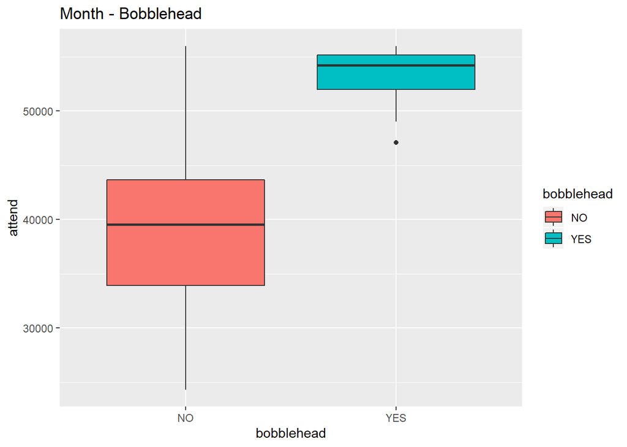

```r
g0 <- ggplot(d, aes(x = bobblehead, y = attend, fill = bobblehead)) +
   geom_boxplot() +
   ggtitle("Month - Bobblehead")

g0
```

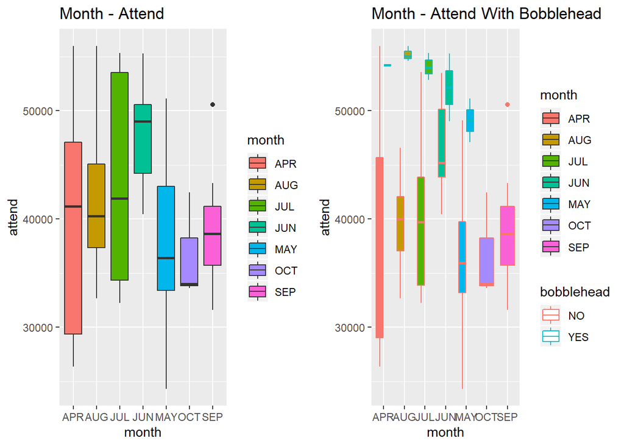

```r
g1 <- ggplot(d, aes(x = month, y = attend, fill = month)) +
   geom_boxplot() +
   ggtitle("Month - Attend")

g1b <- ggplot(d, aes(x = month, y = attend, fill = month, color = bobblehead)) +
   geom_boxplot() +
   ggtitle("Month - Attend With Bobblehead")

grid.arrange(g1,g1b, ncol = 2)
```

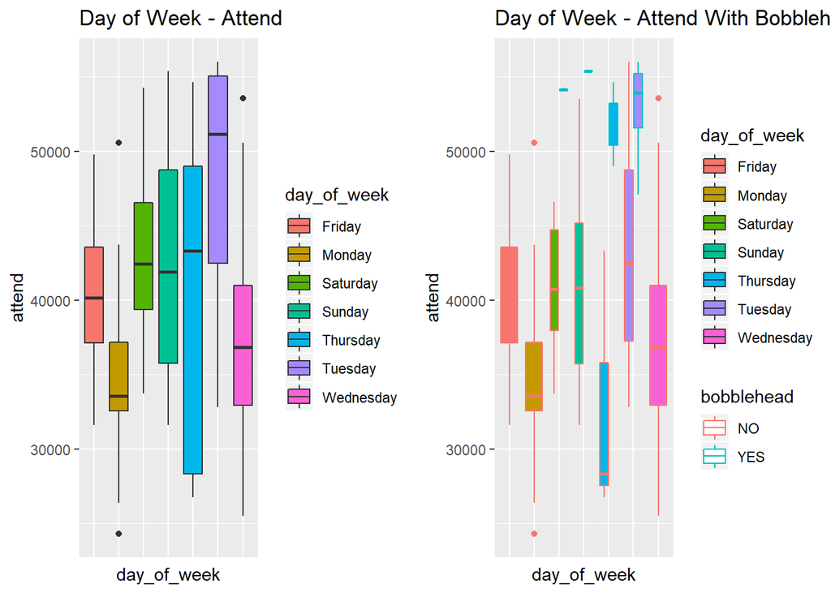

```r
g2 <- ggplot(d, aes(x = day_of_week, y = attend, fill = day_of_week)) +
   geom_boxplot() +
   theme(axis.text.x=element_blank(),
   axis.ticks.x=element_blank()) +
   ggtitle("Day of Week - Attend")

g2b <- ggplot(d, aes(x = day_of_week, y = attend, fill = day_of_week, color = bobblehead)) +
   geom_boxplot() +
   theme(axis.text.x=element_blank(),
   axis.ticks.x=element_blank()) +
   ggtitle("Day of Week - Attend With Bobblehead")

grid.arrange(g2,g2b, ncol = 2)
```

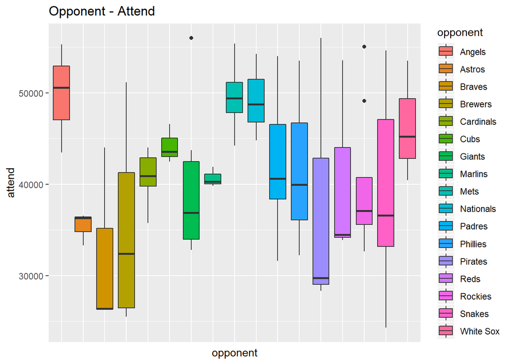

```r
g3 <- ggplot(d, aes(x = opponent, y = attend, fill = opponent)) +
   geom_boxplot() +
   theme(axis.text.x=element_blank(),
   axis.ticks.x=element_blank()) +
   ggtitle("Opponent - Attend ")

g3
```

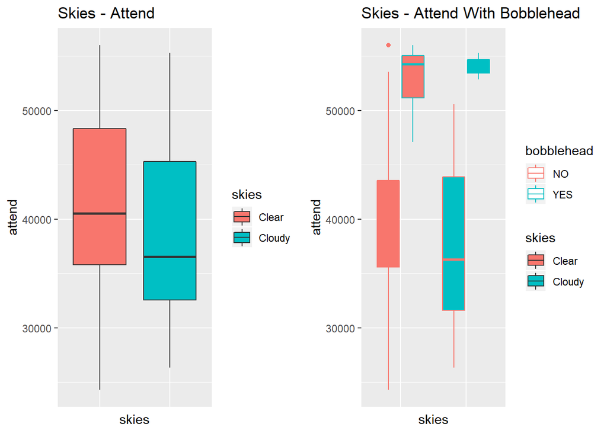

```r
g4 <- ggplot(d, aes(x = skies, y = attend, fill = skies)) +
   geom_boxplot() +
   theme(axis.text.x=element_blank(),
   axis.ticks.x=element_blank()) +
   ggtitle("Skies - Attend")

g4b <- ggplot(d, aes(x = skies, y = attend, fill = skies, color = bobblehead)) +
   geom_boxplot() +
   theme(axis.text.x=element_blank(),
   axis.ticks.x=element_blank()) +
   ggtitle("Skies - Attend With Bobblehead")

grid.arrange(g4,g4b, ncol = 2)
```

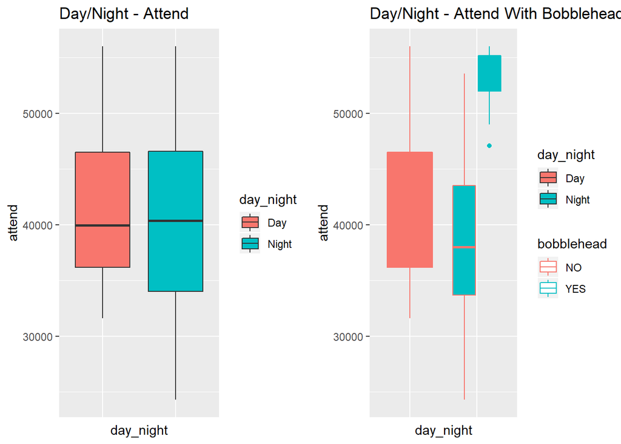

```r
g5 <- ggplot(d, aes(x = day_night, y = attend, fill = day_night)) +
   geom_boxplot() +
   theme(axis.text.x=element_blank(),
   axis.ticks.x=element_blank()) +
   ggtitle("Day/Night - Attend")

g5b <- ggplot(d, aes(x = day_night, y = attend, fill = day_night, color = bobblehead)) +
   geom_boxplot() +
   theme(axis.text.x=element_blank(),
   axis.ticks.x=element_blank()) +
   ggtitle("Day/Night - Attend With Bobblehead")

grid.arrange(g5,g5b, ncol = 2)
```

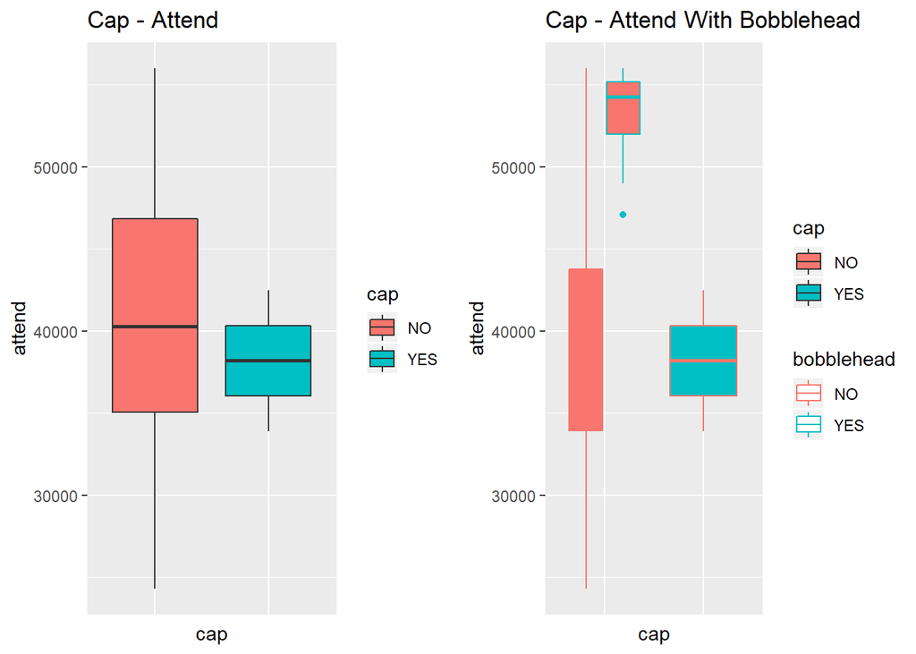

```r
g6 <- ggplot(d, aes(x = cap, y = attend, fill = cap)) +
   geom_boxplot() +
   theme(axis.text.x=element_blank(),
   axis.ticks.x=element_blank()) +
   ggtitle("Cap - Attend")

g6b <- ggplot(d, aes(x = cap, y = attend, fill = cap, color = bobblehead)) +
   geom_boxplot() +
   theme(axis.text.x=element_blank(),
   axis.ticks.x=element_blank()) +
   ggtitle("Cap - Attend With Bobblehead")

grid.arrange(g6,g6b, ncol = 2)
```

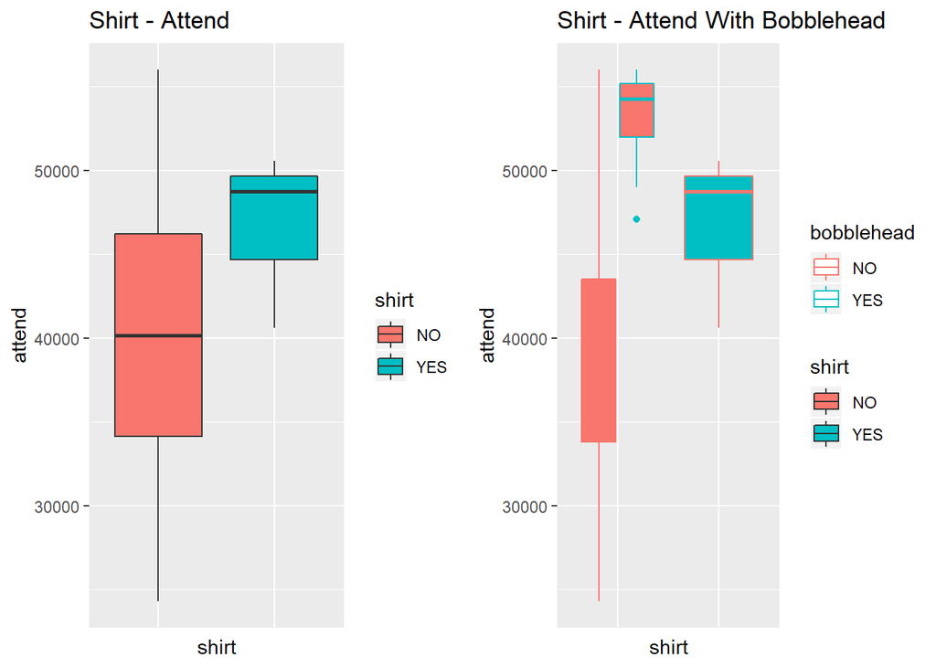

```r
g7 <- ggplot(d, aes(x = shirt, y = attend, fill = shirt)) +
   geom_boxplot() +
   theme(axis.text.x=element_blank(),
   axis.ticks.x=element_blank()) +
   ggtitle("Shirt - Attend")

g7b <- ggplot(d, aes(x = shirt, y = attend, fill = shirt, color = bobblehead)) +
   geom_boxplot() +
   theme(axis.text.x=element_blank(),
   axis.ticks.x=element_blank()) +
   ggtitle("Shirt - Attend With Bobblehead")

grid.arrange(g7,g7b, ncol = 2)
```

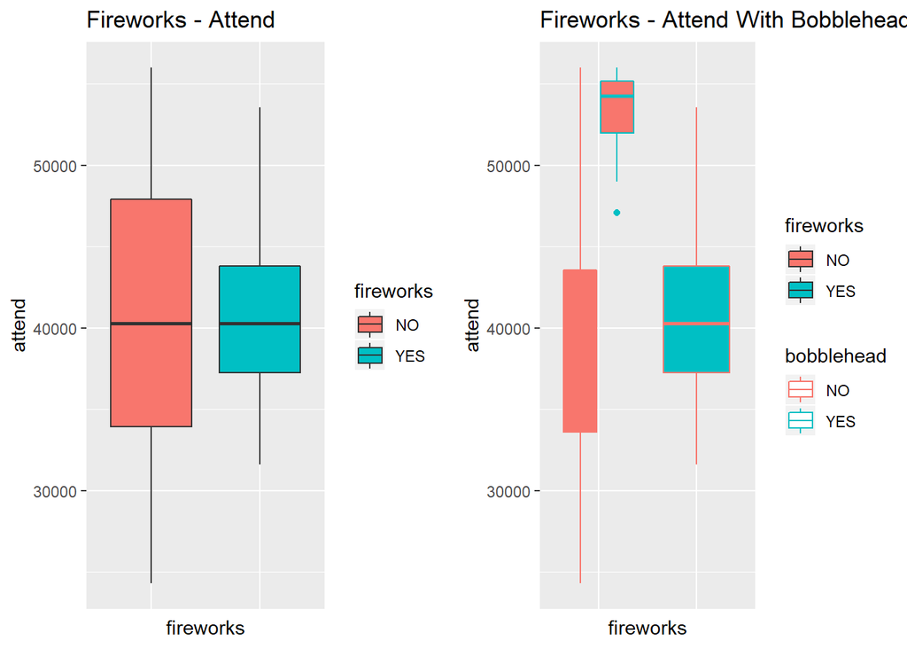

```r
g8 <- ggplot(d, aes(x = fireworks, y = attend, fill = fireworks)) +
   geom_boxplot() +
   theme(axis.text.x=element_blank(),
   axis.ticks.x=element_blank()) +
   ggtitle("Fireworks - Attend")

g8b <- ggplot(d, aes(x = fireworks, y = attend, fill = fireworks, color = bobblehead)) +
   geom_boxplot() +
   theme(axis.text.x=element_blank(),
   axis.ticks.x=element_blank()) +
   ggtitle("Fireworks - Attend With Bobblehead")

grid.arrange(g8,g8b, ncol = 2)
```

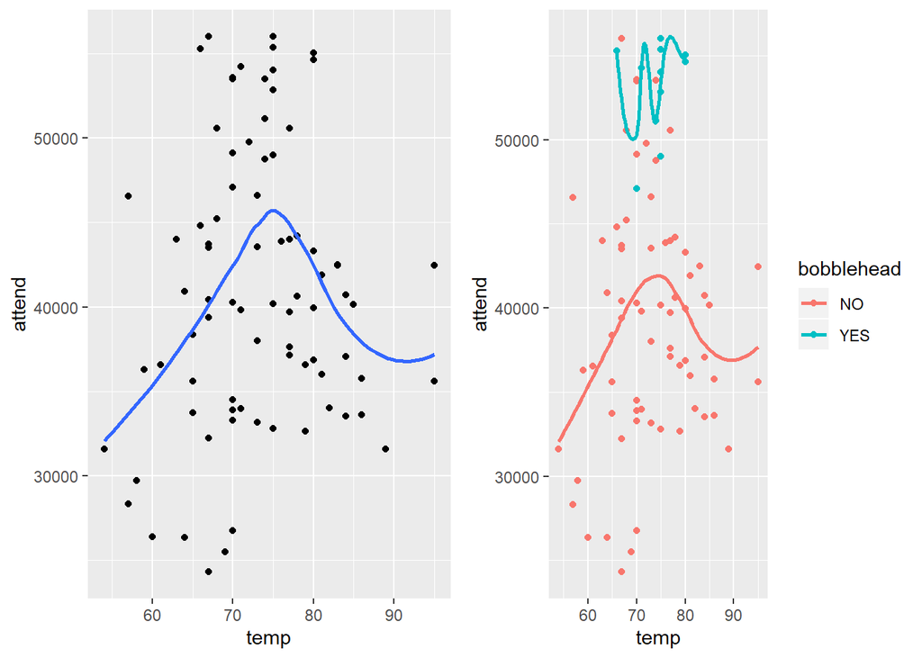

```r
g9 <- ggplot(d, aes(x=temp, y=attend)) +
   geom_point() +
   geom_smooth(se=FALSE, method="loess")

g9b <- ggplot(d, aes(x=temp, y=attend, color = bobblehead)) +
   geom_point() +
   geom_smooth(se=FALSE, method="loess")

grid.arrange(g9,g9b, ncol = 2)
```

```r
d2 <- d %>%
  mutate(AttendanceCat = cut(attend, breaks = 5,
                     labels=c("Level1","Level2","Level3","Level4","Level5")))

# attend column cut into five levels for chi_square tests

month_table <- table(d2$AttendanceCat, d2$month)
day_table <- table(d2$AttendanceCat, d2$day)
day_of_week_table <- table(d2$AttendanceCat, d2$day_of_week)
opponent_table <- table(d2$AttendanceCat, d2$opponent)
temp_table <- table(d2$AttendanceCat, d2$temp)
skies_table <- table(d2$AttendanceCat, d2$skies)
day_night_table <- table(d2$AttendanceCat, d2$day_night)
cap_table <- table(d2$AttendanceCat, d2$cap)
shirt_table <- table(d2$AttendanceCat, d2$shirt)
fireworks_table <- table(d2$AttendanceCat, d2$fireworks)
bobblehead_table <- table(d2$AttendanceCat, d2$bobblehead)
```

```r
pander(chisq.test(month_table))
```

Pearson’s Chi-squared test: `month_table`

| Test statistic | df | P value |
| --- | --- | --- |
| 48.13 | 24 | 0.002434 * * |

```r
pander(chisq.test(day_table))
```

Pearson’s Chi-squared test: `day_table`

| Test statistic | df | P value |
| --- | --- | --- |
| 120.5 | 120 | 0.4704 |

```r
pander(chisq.test(day_of_week_table))
```

Pearson’s Chi-squared test: `day_of_week_table`

| Test statistic | df | P value |
| --- | --- | --- |
| 38.17 | 24 | 0.03329 * |

```r
pander(chisq.test(opponent_table))
```

Pearson’s Chi-squared test: `opponent_table`

| Test statistic | df | P value |
| --- | --- | --- |
| 102.7 | 64 | 0.001532 * * |

```r
pander(chisq.test(temp_table))
```

Pearson’s Chi-squared test: `temp_table`

| Test statistic | df | P value |
| --- | --- | --- |
| 134.3 | 124 | 0.249 |

```r
pander(chisq.test(skies_table))
```

Pearson’s Chi-squared test: `skies_table`

| Test statistic | df | P value |
| --- | --- | --- |
| 7.157 | 4 | 0.1278 |

```r
pander(chisq.test(day_night_table))
```

Pearson’s Chi-squared test: `day_night_table`

| Test statistic | df | P value |
| --- | --- | --- |
| 2.645 | 4 | 0.6189 |

```r
pander(chisq.test(cap_table))
```

Pearson’s Chi-squared test: `cap_table`

| Test statistic | df | P value |
| --- | --- | --- |
| 1.814 | 4 | 0.7699 |

```r
pander(chisq.test(shirt_table))
```

Pearson’s Chi-squared test: `shirt_table`

| Test statistic | df | P value |
| --- | --- | --- |
| 1.841 | 4 | 0.7649 |

```r
pander(chisq.test(fireworks_table))
```

Pearson’s Chi-squared test: `fireworks_table`

| Test statistic | df | P value |
| --- | --- | --- |
| 3.872 | 4 | 0.4235 |

```r
pander(chisq.test(bobblehead_table))
```

Pearson’s Chi-squared test: `bobblehead_table`

| Test statistic | df | P value |
| --- | --- | --- |
| 32.68 | 4 | 0.000001389 * * * |

```r
lm_model <- lm(attend ~ ., d)
lm_AIC <- step(lm_model)
```

```
## Start:  AIC=1433.33
## attend ~ month + day + day_of_week + opponent + temp + skies +
##     day_night + cap + shirt + fireworks + bobblehead
##
##               Df Sum of Sq        RSS    AIC
## - opponent    16 482404341 2055399107 1423.0
## - month        6 107253092 1680247858 1426.7
## - temp         1     48765 1573043531 1431.3
## - skies        1     73327 1573068093 1431.3
## - shirt        1   1648173 1574642938 1431.4
## - day          1  31985882 1604980647 1433.0
## - day_night    1  34516507 1607511273 1433.1
## <none>                     1572994766 1433.3
## - cap          1  44252037 1617246803 1433.6
## - fireworks    1 208621672 1781616438 1441.4
## - bobblehead   1 305478664 1878473429 1445.7
## - day_of_week  6 622226954 2195221720 1448.3
##
## Step:  AIC=1422.99
## attend ~ month + day + day_of_week + temp + skies + day_night +
##     cap + shirt + fireworks + bobblehead
##
##               Df Sum of Sq        RSS    AIC
## - day_night    1   1939503 2057338610 1421.1
## - skies        1   3025454 2058424560 1421.1
## - temp         1  18990413 2074389520 1421.7
## - day          1  28387321 2083786427 1422.1
## <none>                     2055399107 1423.0
## - cap          1  60563235 2115962342 1423.3
## - shirt        1  83891144 2139290251 1424.2
## - month        6 484099010 2539498117 1428.1
## - fireworks    1 197806771 2253205878 1428.4
## - day_of_week  6 663720865 2719119972 1433.7
## - bobblehead   1 574485229 2629884336 1441.0
##
## Step:  AIC=1421.07
## attend ~ month + day + day_of_week + temp + skies + cap + shirt +
##     fireworks + bobblehead
##
##               Df Sum of Sq        RSS    AIC
```

[output cut: 36 more lines]

```
## - month        6 541557658 2632382748 1425.0
## - day_of_week  6 765145220 2855970311 1431.6
## - bobblehead   1 615401407 2706226498 1437.3
##
## Step:  AIC=1417.21
## attend ~ month + day_of_week + cap + shirt + fireworks + bobblehead
##
##               Df Sum of Sq        RSS    AIC
## <none>                     2112467217 1417.2
## - cap          1  55325426 2167792643 1417.3
## - shirt        1  88943911 2201411129 1418.5
## - fireworks    1 223427284 2335894502 1423.3
## - month        6 549143913 2661611130 1423.9
## - day_of_week  6 800793351 2913260569 1431.2
## - bobblehead   1 686366179 2798833397 1438.0
```

```r
small <- update(lm_model, . ~ 1 )
```

```r
pander(lm_AIC)
```

Fitting linear model: attend ~ month + day_of_week + cap + shirt + fireworks + bobblehead

|  | Estimate | Std. Error | t value | Pr(>\|t\|) |
| --- | --- | --- | --- | --- |
| **(Intercept)** | 22233 | 6583 | 3.377 | 0.00125 |
| **monthAUG** | 3341 | 2304 | 1.45 | 0.152 |
| **monthJUL** | 2564 | 2556 | 1.003 | 0.3195 |
| **monthJUN** | 6933 | 2574 | 2.694 | 0.009009 |
| **monthMAY** | -1925 | 2176 | -0.8846 | 0.3797 |
| **monthOCT** | 221.8 | 3826 | 0.05798 | 0.9539 |
| **monthSEP** | -102.9 | 2367 | -0.04348 | 0.9655 |
| **day_of_weekMonday** | 10931 | 6803 | 1.607 | 0.113 |
| **day_of_weekSaturday** | 17884 | 6658 | 2.686 | 0.009202 |
| **day_of_weekSunday** | 18225 | 6713 | 2.715 | 0.00851 |
| **day_of_weekThursday** | 12245 | 6947 | 1.763 | 0.08275 |
| **day_of_weekTuesday** | 19352 | 6812 | 2.841 | 0.006026 |
| **day_of_weekWednesday** | 12464 | 6241 | 1.997 | 0.05009 |
| **capYES** | -5785 | 4468 | -1.295 | 0.2001 |
| **shirtYES** | 5965 | 3633 | 1.642 | 0.1056 |
| **fireworksYES** | 16309 | 6269 | 2.602 | 0.01151 |
| **bobbleheadYES** | 10700 | 2346 | 4.56 | 0.00002366 |

```r
pander(x = anova(small,lm_model))
```

Analysis of Variance Table

| Res.Df | RSS | Df | Sum of Sq | F | Pr(>F) |
| --- | --- | --- | --- | --- | --- |
| 80 | 5507932888 | NA | NA | NA | NA |
| 44 | 1572994766 | 36 | 3934938122 | 3.057 | 0.0002493 |

```r
pander(x = anova(small,lm_AIC))
```

Analysis of Variance Table

| Res.Df | RSS | Df | Sum of Sq | F | Pr(>F) |
| --- | --- | --- | --- | --- | --- |
| 80 | 5507932888 | NA | NA | NA | NA |
| 64 | 2112467217 | 16 | 3395465670 | 6.429 | 0.0000000287 |

As a result of anova test, the AIC model gives lower p value when it is compared with a null model.

```r
pander(drop1(lm_AIC, test="F"))
```

Single term deletions

|  | Df | Sum of Sq | RSS | AIC | F value | Pr(>F) |
| --- | --- | --- | --- | --- | --- | --- |
|  | NA | NA | 2112467217 | 1417 | NA | NA |
| **month** | 6 | 549143913 | 2661611130 | 1424 | 2.773 | 0.01849 |
| **day_of_week** | 6 | 800793351 | 2913260569 | 1431 | 4.044 | 0.001696 |
| **cap** | 1 | 55325426 | 2167792643 | 1417 | 1.676 | 0.2001 |
| **shirt** | 1 | 88943911 | 2201411129 | 1419 | 2.695 | 0.1056 |
| **fireworks** | 1 | 223427284 | 2335894502 | 1423 | 6.769 | 0.01151 |
| **bobblehead** | 1 | 686366179 | 2798833397 | 1438 | 20.79 | 0.00002366 |

P_values of cap and shirt resulted as higher than other variables p_values. The reason of this can be the low number samples of cap and shirts in the data. There is only 2 YES for cap and 3 YES for shirt among 81 rows.

```r
library(caret)
train.control <- trainControl(method = "cv", number = 5)
model1 <- train(attend ~., data = d, method = "lm",
               trControl = train.control)
model2 <- train(attend ~ month + day_of_week + cap + shirt + fireworks + bobblehead, data = d, method = "lm",
                trControl = train.control)

print(model1)
```

```
## Linear Regression
##
## 81 samples
## 11 predictors
##
## No pre-processing
## Resampling: Cross-Validated (5 fold)
## Summary of sample sizes: 65, 65, 64, 65, 65
## Resampling results:
##
##   RMSE      Rsquared  MAE
##   9743.754  0.184817  7235.794
##
## Tuning parameter 'intercept' was held constant at a value of TRUE
```

```r
print(model2)
```

```
## Linear Regression
##
## 81 samples
##  6 predictor
##
## No pre-processing
## Resampling: Cross-Validated (5 fold)
## Summary of sample sizes: 65, 65, 65, 64, 65
## Resampling results:
##
##   RMSE      Rsquared   MAE
##   6598.767  0.4274345  5119.554
##
## Tuning parameter 'intercept' was held constant at a value of TRUE
```

Cross-Validation resulted as better MAE and R^2 values AIC model compared to full model.

```r
confint(lm_model, level = 0.80)["bobbleheadYES",]
```

```
##      10 %      90 %
##  5187.911 13510.517
```

```r
# 80% CI For bobblehead.
```

Bobblehead is still significant, we reject null hypothesis for it. Estimated additional attendence due bobblehead is 10700 in AIC model.

Temperature’s effect for attend peaks at ~75 degree and decreases before and after ~75. With a nonlinear transformation method that transforms ~75 as highest and the min and max temp values as lowest may increase the estimation precision of the temp effect on attend.

```r
lm_twoway <- lm(attend ~ month + day_of_week + cap + shirt + fireworks + bobblehead +  bobblehead*day_of_week, d)

train.control <- trainControl(method = "cv", number = 5)

model_twoway_cv1 <- train(attend ~ month + day_of_week + cap + shirt + fireworks + bobblehead +  bobblehead*day_of_week, d, method = "lm",
               trControl = train.control)


print(model_twoway_cv1)
```

```
## Linear Regression
##
## 81 samples
##  6 predictor
##
## No pre-processing
## Resampling: Cross-Validated (5 fold)
## Summary of sample sizes: 65, 65, 65, 65, 64
## Resampling results:
##
##   RMSE      Rsquared   MAE
##   7411.931  0.3354317  5874.836
##
## Tuning parameter 'intercept' was held constant at a value of TRUE
```

With an addition of `bobblehead*day_of_week` to the `attend ~ month + day_of_week + cap + shirt + fireworks + bobblehead` model R^2 or error did not improved enough to be claimed that model gets benefit from this two-way interaction.

```r
lm_twoway <- lm(attend ~ month + day_of_week + cap + shirt + fireworks + bobblehead +  bobblehead*month, d)

train.control <- trainControl(method = "cv", number = 5)

model_twoway_cv2 <- train(attend ~ month + day_of_week + cap + shirt + fireworks + bobblehead +  bobblehead*month, d, method = "lm",
               trControl = train.control)

print(model_twoway_cv2)
```

```
## Linear Regression
##
## 81 samples
##  6 predictor
##
## No pre-processing
## Resampling: Cross-Validated (5 fold)
## Summary of sample sizes: 65, 65, 64, 65, 65
## Resampling results:
##
##   RMSE      Rsquared   MAE
##   7297.849  0.3361148  5922.786
##
## Tuning parameter 'intercept' was held constant at a value of TRUE
```

Also with an addition of `bobblehead*month` to the `attend ~ month + day_of_week + cap + shirt + fireworks + bobblehead` model R^2 or error did not improved enough to be claimed that model gets benefit from this two-way interaction.